# Human Immune Transcriptional Responses to Pathogenic Fungi

Analysis of human gene expression profiles following fungal infection using published count data (GSE162746)

Group 30: Anastasia Baltzi, Greta, Martina Ippolito, Swastika, Teo

## Background

Three important human fungal pathogens:

- *A. fumigatus*, *C. albicans* and *R. oryzae*

Fungal exposure triggers immune responses and changes host gene expression.

Different fungi may activate different host defence mechanisms.

## Aim and research questions

**Aim:** compare host gene expression responses to three fungal pathogens and identify shared antifungal responses, species-specific responses and time-dependent changes.

**Research questions**

1. **Overall response:** Do the fungal stimulations give distinct expression profiles? How do samples cluster by fungus and time point?
2. **Inflammatory markers:** How do CXCL8, IL1B, IL6 and TNF respond, and how does this change from 4 h to 24 h?
3. **Differential expression:** Which genes go up or down versus control, and how do these responses differ by species and time?

## Individual gene expression responses

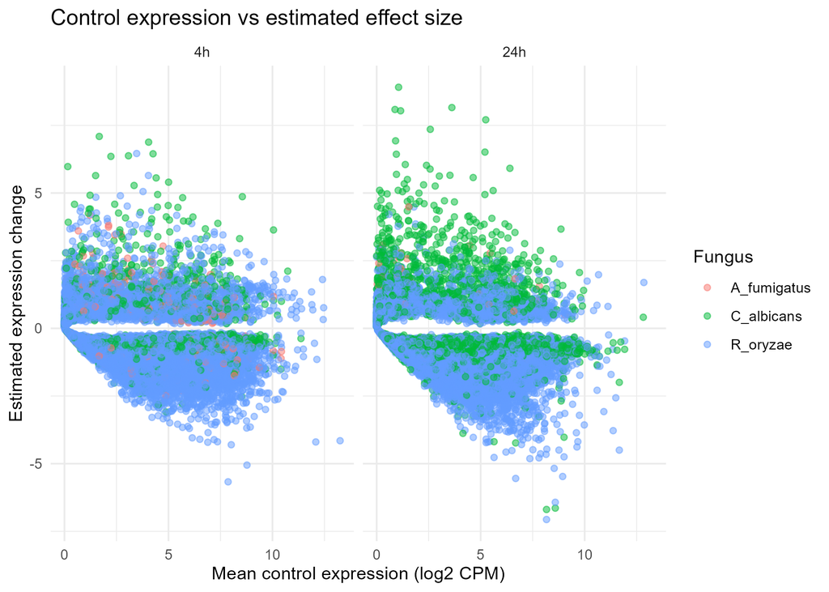

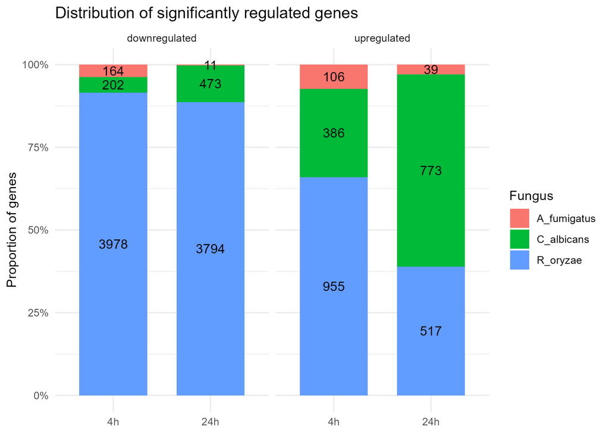

- Significant genes: BH-adjusted q-value < 0.05. Upregulated and downregulated genes have estimated effects above 1 or below -1.
- *R. oryzae* accounts for about 92% of downregulated genes at 4h and 89% at 24h
- The upregulated side changes over time: *R. oryzae* gives 66% of upregulated genes at 4h, but *C. albicans* gives 58% at 24h.

## Shared transcriptional responses across fungi

Genes regulated in the same direction by all three fungi,  
separately at each time point

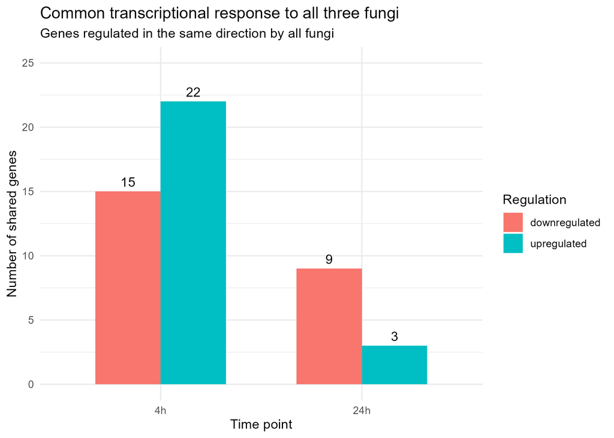

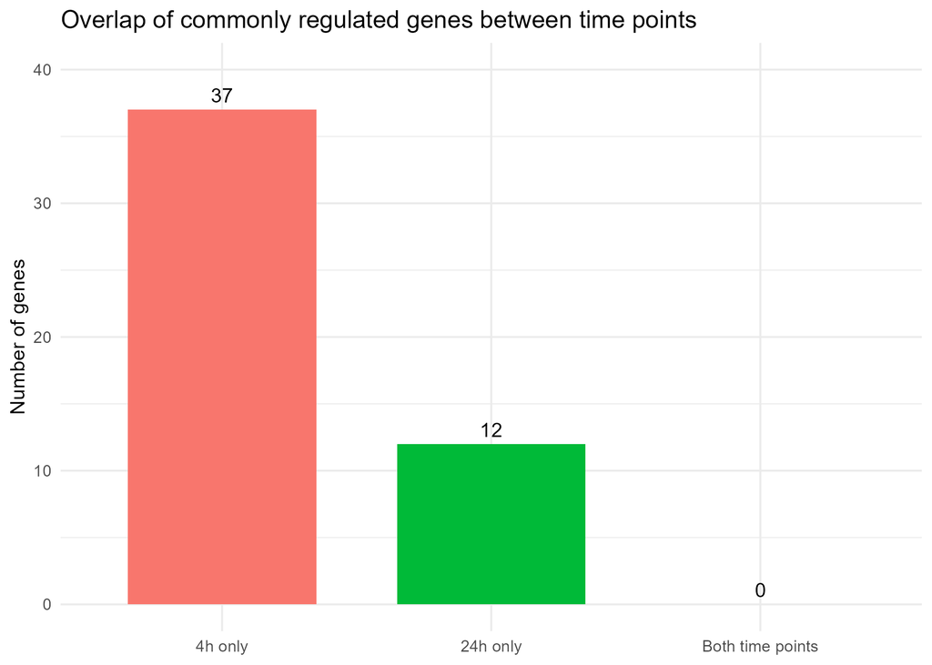

- The early shared response is mostly upregulation, which fits a rapid, general activation of host defence.
- The late shared response flips to mostly downregulation
- Only 37 shared genes are specific to 4h and 12 to 24h, and none persist at both time points.
- The shared response is not stable.

## Greta: *C. albicans* against control

| Direction | Article 4 h | Our 4 h | Article 24 h | Our 24 h |
| --- | --- | --- | --- | --- |
| Up | 821 | 420 | 1733 | 934 |
| Down | 234 | 222 | 715 | 506 |

- Same log2 fold change and adjusted p-value thresholds as the article
- Model fitted per gene without DESeq2, so counts differ from the article
- Counts are close to Martina’s *C. albicans* results

[figure not shown]

Volcano plot, *C. albicans* versus control, 24 h

## Conclusion and Discussion

- 1. Different responses depending on the fungal species: The differences in the numbers and directions of regulated genes suggest that the three fungi trigger distinct host transcriptional responses.
- 2. Changes over time: The stronger upregulation observed for C. albicans at 24 h, together with the lower number of shared genes at 24 h, suggests that the transcriptional response may change over time.
- 3. The absence of genes shared at both 4h and 24h suggests that the common response across the three fungi is time-dependent. Some limitations we faced:
  - The analysis uses log2-transformed CPM values and linear models rather than a dedicated RNA-seq differential expression method such as DESeq2.
  - Donor differences were included in the model, but interactions between donor and fungal stimulus were not investigated.
  - The number of significant genes depends on the selected adjusted p-value threshold (q-value below 0.05) and effect-size thresholds (above 1 or below -1).
- *R. oryzae* gives the strongest transcriptional response in these analyses, mostly as downregulation
- A set of 49 genes is shared by all three fungi, mostly at 4 h
- *C. albicans* results look similar across Martina’s and Greta’s models, but are below the article’s counts
- Teo’s statistics, and Swastika’s and Anastasia’s results, to be added

**Questions?**